### Yerevan State University Faculty of Mathematics and Mechanics Applied Statistics and Data Science R programming **Final Exam Variant 1**

21 December 2020

*Exam Duration: 20 minutes.*

**READ THESE INSTRUCTIONS CAREFULLY**

This test consists of 3 sections:

- Data Manipulation + Shiny (**3 pt.**)
- Visualization + Elementary Statistics in R (**2 pt.**)
- Regex (**1 pt.**)

Overall test grade is 6 points.  
This is an open-book test: you can use your notes, books, codes or other materials.  
Please turn off your cell phones and place them out of reach.  
Talking to another student, looking at another student’s computer, or communicating with other students in any way is strictly forbidden.

**Good luck!**

# Task 1 (3 points): Data Manipulation + Shiny

Use **new orleans cash transactions (version 1).xlsx** dataset to create the following [shiny app](https://forexamples.shinyapps.io/variant1/).

# Task 2 (2 points): Visualization + Elementary Statistics in R

Load the dataset `vinclozolin` from `drc` package.

1. Create a function that takes a numeric variable as an argument and returns the table with the mean and standard deviation of argument grouped by the variable `exper`. Show the results for concentration of vinclozolin.

```
## # A tibble: 6 x 3
##   exper  Mean StandardDeviation
##   <fct> <dbl>             <dbl>
## 1 10509  0.69              1.04
## 2 10821  0.69              1.04
## 3 10828  0.69              1.04
## 4 10904  0.69              1.04
## 5 11023  0.69              1.04
## 6 11106  0.78              1.08
```

2. Plot the following graph (pay attention to axes, legend/s, title/s, colors):

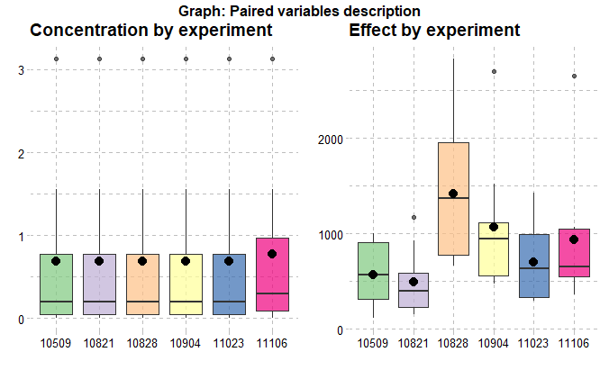

# Task 3 (1 point): Regex

Create a vector containing characters “Robert Aghasaryan”, “Danielian Elina”, “Mariet 002 Stepanyan” and “/01 Tigran 239 Petrosian99”. Build one regex pattern to extract only first names of the people.